# Figuring out recovery metrics

Peter Regier

2024-02-13

## Purpose

There are many different ways to calculate the disturbance/recovery metrics we’re after, and it’s good for things to be clear and explained, and I’m struggling to remember why we’re making the decisions we are, and I’m also going rouge a little bit, so this RMD is here to (hopefully) 1) identify the stats choices, 2) defend them (easier for methods later too), and then 3) give a full example, ending up with a function that I can use elsewhere. Note that inspiration comes from TSLA code: https://github.com/COMPASS-DOE/tempest-system-level-analysis/blob/recovery-rate-bounds/scripts/tmp_test_functions.R. I didn’t read super carefully, so I might have missed something. I’m going to *bold things where I am unsure*

## Example data

I’ll use VWC from TEROS for TEMPEST2 (2023) which I’ve trimmed to the date range with good DO and redox data for my TEMPEST2 paper. Data look like so:

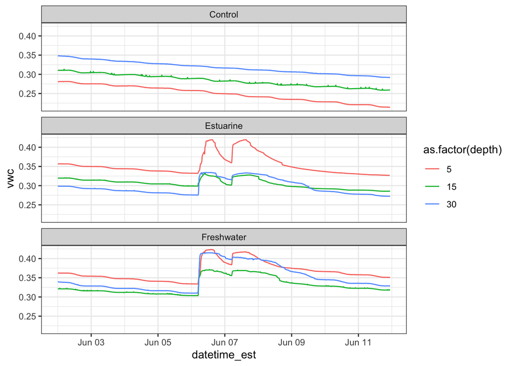

## Step 1: z-score normalize

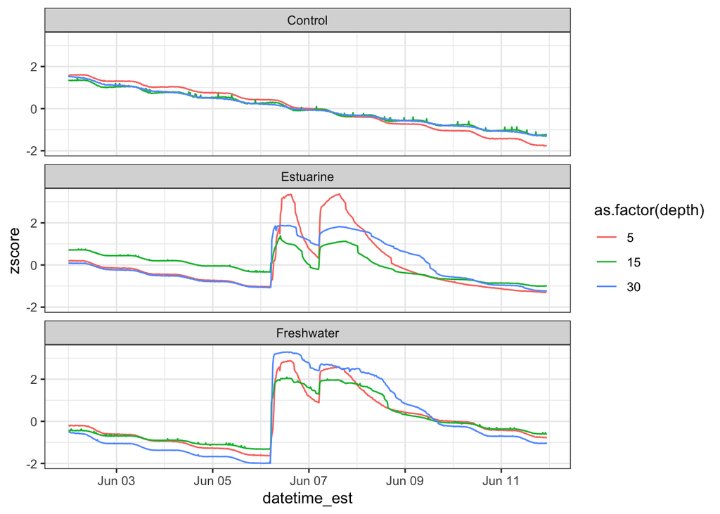

```r
## This is the SD of the Control for raw (non-zscore-normalized) data
sd_control <- teros %>%
  filter(plot == "Control") %>%
  group_by(depth) %>%
  summarize(sd = sd(vwc, na.rm = T)) %>%
  ungroup() %>%
  summarize(sd = max(sd)) %>% # Use max to capture maximum variability in the control plot
  pull(sd)

z_teros <- teros %>%
  group_by(plot, depth) %>%
  mutate(zscore = (vwc - mean(vwc, na.rm = TRUE)) / sd_control)
```